# COVID-19 Policy Effectiveness

A comparative time series-analysis of France, Germany, Italy and Spain

Philipp Holz

28 June 2021

# Introduction

Like no other event in recent history, the COVID-19 pandemic has drawn attention to policy makers and the effectiveness of their work around the world. Scientific insight and epidemiological experts were at the forefront of the debate and newspapers found themselves citing regularly from pre-published papers in search for answers to the correct way of tackling this pandemic. For social science researchers interested in the policy process and impact analysis, this presents a unique opportunity to compare the empiry of policy making across countries and governments. And because, the COVID-19 pandemic led to the creation and assembly of data like perhaps no other singular societal challenge before it, statistical methods are more than ever suitable in doing so.

Policy-makers opted for a wide variety of COVID-19-related measures, among them “school closings, travel restrictions, bans on public gatherings, emergency investments in healthcare facilities, new forms of social welfare provision, contact tracing and other interventions to contain the spread of the virus, augment health systems and manage the economic consequences of these actions” (Hale et al. 2021, 529). The measures were intended “to prevent infection introduction, contain outbreaks, and reduce peak epidemic size so that healthcare systems do not become overwhelmed” (Liu et al. 2021, 41).

However, at the same time, there was “substantial variation” both in the stringency of governments’ responses to the pandemic (Pulejo and Querubín 2021, 1), and in the combination of measures adopted (see Rozanova, Temerev, and Flahault 2020, 3). Obviously, some of this variation can be attributed to “the severity and timing of the outbreak[s]” (Pulejo and Querubín 2021, 1) and to the initial scientific uncertainty regarding the most effective measures to contain the spread of the virus.

At the same time however, policy makers also had to strike a balance between the potential epidemiological effectiveness of the interventions and their “psychological, social and economic cost” (Liu et al. 2021, 41) as “restrictive measures have been shown to hurt the economy, and distribute their burden unequally across the population” (Pulejo and Querubín 2021, 1). Thus, more recent research focuses on the “extent to which political considerations have shaped public policy” (Pulejo and Querubín 2021, 1) over the course of the pandemic.

This is also the aim of this analysis, which tries to answer the following question:

*How does the epidemiological effectiveness of policy making with COVID-19-related, restrictive policies compare among selected European countries?*

In doing so, this analysis assumes a more abstract perspective, where epidemiological effectiveness of policy making is evaluated in terms of both the timeliness and the impactfulness of the COVID-19-related policies implemented. The countries compared are France, Germany, Italy, and Spain, which were selected based on their membership to the EU - which means they have started their vaccination programs at the same time - and based on them being the largest of the EU-member states in terms of population and GDP.

With this scope, this essay will serve as a starting point for researchers, who try to understand the impact of other, non-epidemiological motivations on COVID-19-related policy making, which could lead to findings on both the effectiveness of different polities, and to findings on how governments were able to best strike the compromise between epidemiological, political and socio-economic concerns.

In the following, I will first give an overview of and discuss published research on the topic and with similar approaches. Then, I will present and justify my method, guide the reader through the analysis, which will lead to the respective models and regression tables that I will present as my results. Finally, I will discuss potential interpretations of these findings and possible shortcomings of my approach.

# Literature Review

The coronavirus disease 2019 (COVID-19) is a “respiratory infectious disease caused by the severe acute respiratory syndrome cronavirus 2 (SARS-CoV-2), which was first detected in early December 2019 in Wuhan, China.” (Koh, Naing, and Wong 2020, 42) As of June 2021, there have been 180 million confirmed cases of COVID-19, including 3.9 million deaths reported to the WHO. (“WHO Coronavirus (COVID-19) Dashboard” 2021)

Early descriptive studies found that “the response to COVID-19 pandemic varied significantly between different countries,” with differences being the result of “differences in healthcare system capabilites and organization, emergency response availability and preparedness, underlying economic conditions in each country, prevalence of different social behavior patterns, and last but not least - the differences in individual assumptions and preferred approaches of the policymakers.” (Rozanova, Temerev, and Flahault 2020, 3)

When more empirical data became available, further studies compared the epidemiological effectiveness of different measures and found that e.g. there was strong evidence for the effectiveness of school closures and internal movement restrictions (Liu et al. 2021, 19), as well as workplace closures, and public events bans (Li et al. 2021, 193), however with contradictory findings e.g. regarding requirements to stay at home (compare Liu et al. 2021, 19; Li et al. 2021, 193).

Two measures central to these studies that have frequently been used together are the policy stringeny index, which is part of the Oxford COVID-19 Government Response Tracker (OxCGRT) (Hale et al. 2021), and the time-varying reproduction number. (compare Koh, Naing, and Wong 2020)

The OxCGRT is “provides a systematic set of cross-national, longitudinal measures of government responses from 01 January 2020. [It] tracks national […] governments’ policies and interventions across a standardized series of indicators.” (Hale et al. 2021, 529) The policy stringency index ranges from 0 to 100 with a higher index indicating increased stringency (Koh, Naing, and Wong 2020, 44), and includes policies that either “(i) limit individual freedom (of work, movement or gathering), (ii) shut down public services and events in order to reduce mobility, or (iii) deliver information about the necessity to comply with these measures.” (Pulejo and Querubín 2021, 2)

While a number of other datasets have also tracked governments responses to the SARS-CoV-2 pandemic, these OxCGRT project stands out by setting the jurisdiction day as its unit of analysis, instead of the respective government policy. As Hale et al. note, each approach can be converted into the other, but using the former facilitates conventional analysis. (Hale et al. 2021, 537)

The viral transmission rate $R$ on the other hand is frequently used as a measure to describe the expected dynamic of the pandemic. $R_{0}$ describes the expected number of secondary cases a primary case would generate if the entire population was suceptible to it and no containment measures would be taken, whereas the time-varying reproduction number $R_{t}$ describes how many secondary cases a primary case is expected to generate at any given point in time, meaning that a sustained value of $R_{t}$ greater than one indicates that an outbreak is likely, whereas a sustained value of $R_{t}$ smaller than one indicates that the virus will eventually die out. (compare Koh, Naing, and Wong 2020; Li et al. 2021)

# Method

In order to answer our question of how the epidemiological effectiveness of policy making with COVID-19-related, restrictive policies compares across selected countries, we are interested in seeing how changes in the policy stringency in these countries affect the time-varying reproduction number $R_{t}$. Thus, in our analysis, we set reproduction rate as our outcome variable and the policy stringency index as our explanatory variable.

Because vaccinations against COVID-19 have an effect on $R_{t}$, but deviate from the restrictive, non-pharmaceutical measures that we include in this analysis via the stringency index, we are only considering a specific time frame where vaccinations against COVID-19 are still unlikely to have a significant effect on $R_{t}$. Because it is without a doubt difficult to pinpoint such a point in time, we chose the date when, in the countries included, ~10% of the population has received at least on vaccine dosis. As the vaccination program in the countries included advanced synchronously, all four countries reached this point on 25 March 2021. Thus, the time frame covered in this research stretches from 03 March 2020, from when on we have data on the time-variable reproduction rate $R_{t}$, obtained from OurWorldInData.org (Ritchie, Ortiz-Ospina, and Beltekian 2020), to 25 March 2021. The data was obtained as of 18 June 2021.

An alternative approach to simply restricting the time frame covered in this analysis would be to use a multi-variate approach in our regression analysis, where we could include the share of the vaccinated population as a covariate. However, this is unfortunately beyond the complexity which can be covered in this short analysis. Choosing to restrict the time frame instead, also meant excluding the United Kingdom from this analysis, as there the vaccination program was already very advanced, which would have resulted in comparatively little data.

Furthermore, we have to expect that there is a possible time delay between the change in policy stringency and the change in the reproduction rate. This delay accumulates as the sum of (i) the incubation period from an infection with SARS-CoV-2 to the possible appearance of symptoms, and (ii) the possible delay between the appearance of symptoms and their reporting. (see Liu et al. 2021, 42) As symptoms show roughly 5 days after the infection and thus infections are usually discovered at the earliest 5 days after the infection happened, such a lag seems plausible. (Lauer et al. 2020) As making a test then can take more time, more lags seem also possible. Thus, as will be layed out in more detail in the analysis, part of our model fitting strategy will be to find the correct lag of the explanatory variable, the policy stringency index, versus our outcome variable, the reproduction rate $R_{t}$, where regressing the stringency index at lag 1 on the reproduction rate would be showing, how changes in the stringency index affect changes in the reproduction rate one week after the changes in the stringency index occured.

As we are defining *epidemiological effectiveness* of the policy making both in terms of the timeliness and impactfulness of the policies adopted, the aim of our analysis will be to find the best fitting model for each of the four countries and compare both the respective lags of the explanatory variable, at which the best model fit was achieved - denoting the timeliness of the policies, and the respective coefficients, which denote the impactfulness of the policies adopted in each country.

This means, our approach is largely unaffected by the social and epidemiological contexts of the different countries. Instead, by simply looking at how closely the trends in the reproduction rate and policy stringency correspond for each country, different absolute case numbers are equally unimportant as are different levels of how stringent policies are being adhered to by the population. For example France has had almost twice as many COVID-19-cases as did Germany per population (Ritchie, Ortiz-Ospina, and Beltekian 2020), however, if the trends in reproduction rate corresponded in the same degree to the trends policy stringency in both countries, the policies would have shown to be equally effective in both countries - with the only difference that policy makers in France decided to tolerate higher case numbers than in Germany. The same goes for how strictly policies are being adhered to: In one country, the policy stringency might have to be higher to achieve the same degree of restrictions on mobility social gatherings, however, if the policy stringency corresponded in its trend to the trend of the reproduction rate, the policies decided upon would show the same effectiveness as in another country where policy adherence might be higher.

# Analysis

In the following, we will approach our final models by looking at the arbitrarily chosen example of France. On first sight, the time series for the time-varying reproduction rate and the stringency index could be correlated. The reproduction rate is high when the stringency is low and vice versa. Also, they do not show a clear linear trend or seasonality for this time frame, while they do, however, show strong persistence, where one observation depends on one or more of its predecessors.

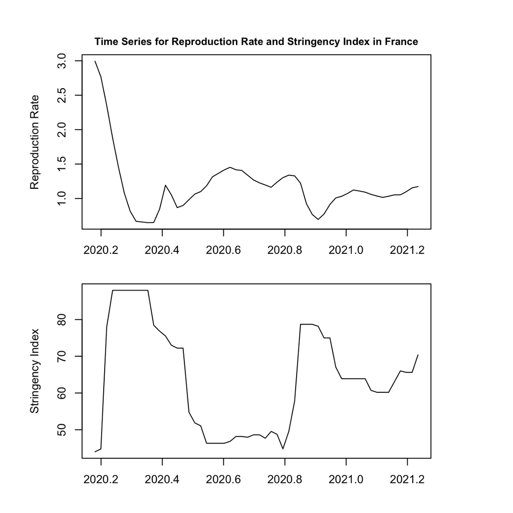

In order to properly analyse any statistical relation between the two time series, we have to make sure to avoid falling for spurious correlations, where a possible correlation could be the result of a confounding factor. We can do so by transforming the time series in a way that they become stationary, meaning that they should not be explosive, nor trending, and nor wandering aimlessly without returning to its mean. (Yobero 2017)

While our time series already fulfill the first two of these characteristics, they do have the characteristics of a random walk, having no specified mean or variance, but strong dependence over time. (Matteson 2021)

First off, we can make a visual assessment of correlation between the time series and its lags. As we can see, there is strong correlation between e.g. the reproduction rate and its first lag, while already for the second lag this correlation is less strong.

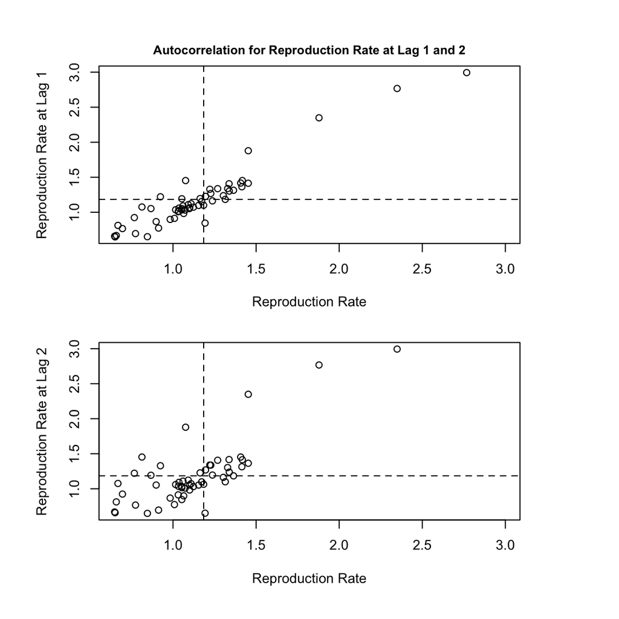

One handy method to check autocorrelation for many lags is via a correlogram which shows the autocorrelation function. In the following plots we can see that the reproduction rate is significantly correlated to up to three lags and the stringency index is significantly correlated for even more lags.

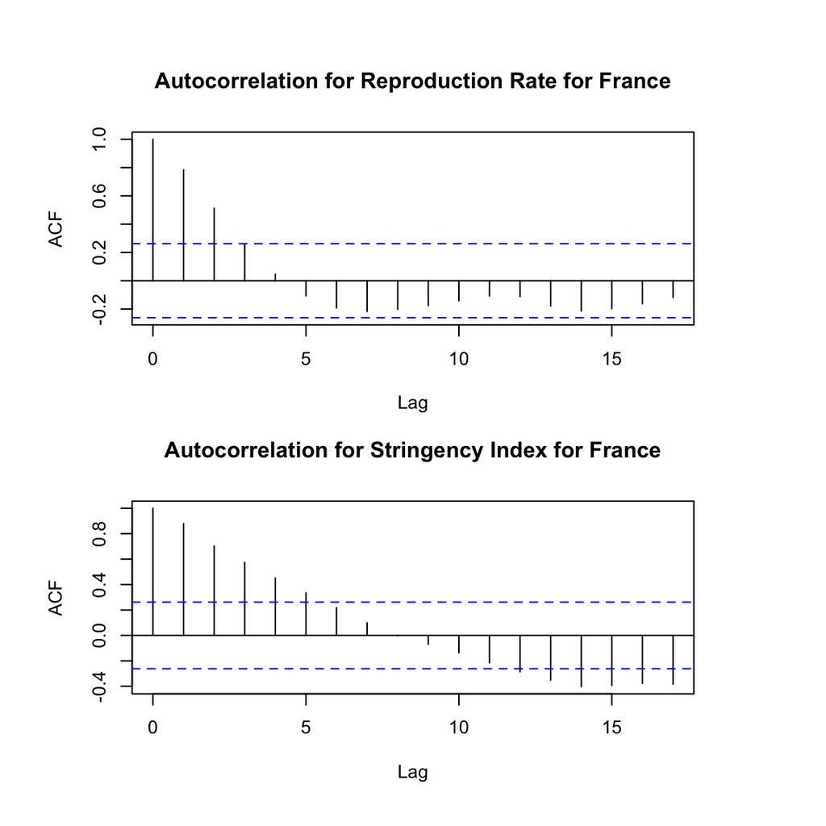

One way to approach stationarity when dealing with a random walk is to take the *first difference* of the time series. The interpretation changes accordingly, meaning that we would now estimate effects in terms of the *changes* in the time series. The resulting time series would be as follows.

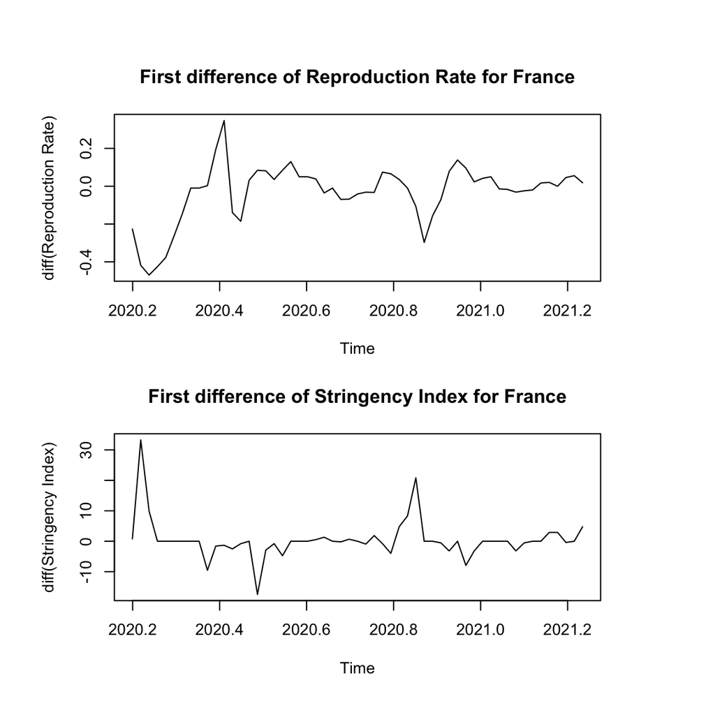

Again, we can reliably check, whether we have gotten rid of the autocorrelation in the data by plotting the autocorrelation function.

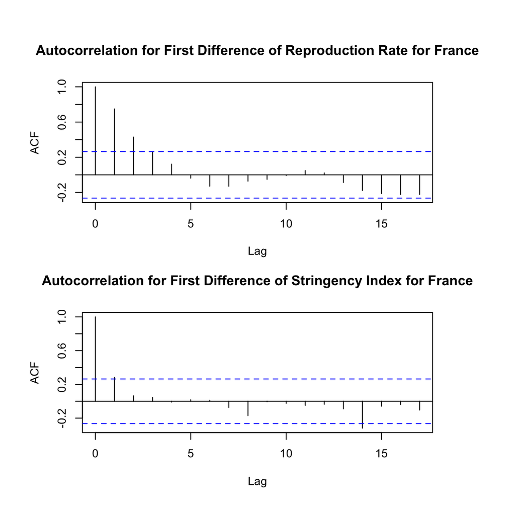

While we are able to eliminate the autocorrelation in the stringency index through differencing, the autocorrelation in the reproduction rate remains.

Thus, we choose to fit an autoregressive distributed lag (ARDL) model with the first difference of both time series. The ARDL model incorporates an autoregressive term, where the dependent variable reproduction rate is regressed both on its own lag, and on several lags of the independent variables.

By including e.g. one lagged term of the dependent variable reproduction rate, we would assume that changes in the reproduction rate only have an impact on changes in the reproduction rate one week after. The same assumption is made when including lags of the changes in the explanatory variable stringency index.

The challenge then, is to choose the right lengths of these lags. Here, “some degree of subjectivity and judgment” is required. (Yobero 2017) In our modelling strategy, we are checking the model fit for lags 1, as well as 1 and 2, for the dependent variable reproduction rate, combined with different combinations of lags 0 to 3 of the explanatory variable stringency index. This means for stringency index we are checking the lags 0; 1; 2; 3; 0 and 1; 0 and 2; 0 and 3; 1 and 2; 1 and 3; 2 and 3; 0, 1 and 2; 0, 2 and 3; 1, 2 and 3; and 0, 1, 2 and 3.

> Germany ARDL(1,0;1,1,0,0)

> $DR_{t} = \alpha + \beta_{1}DR_{t-1} + \beta_{2}DS_{t} + \beta_{2}DS_{t-1} + v_{t}$

> France ARDL(1,0;1,1,0,0)

> $DR_{t} = \alpha + \beta_{1}DR_{t-1} + \beta_{2}DS_{t} + \beta_{2}DS_{t-1} + v_{t}$

> Spain ARDL(1,0;0,1,1,0)

> $DR_{t} = \alpha + \beta_{1}DR_{t-1} + \beta_{2}DS_{t-1} + \beta_{2}DS_{t-2} + v_{t}$

> Italy ARDL(1,0;0,1,0,0)

Note that we are using a perhaps unusual shorthand in referring to the models, that reads as ARDL($p_{t-1}$, $p_{t-2}$; $q_{t}$, $q_{t-1}$, $q_{t-2}$, $q_{t-3}$), where $p$ denotes the auto-regressive term of the outcome variable and $q$ denotes the distributed lag term of the explanatory variable. A *1* indicates the presence of the respective lag and a *0* its absence.

Because none of the best performing models include a lag 2 of the dependent variable, nor a lag 3 of the independent variable, we make the assumption that models with more lags than these will not produce better results. Also, the best performing models all have subsequent lags, which is in line with our finding of some persistence in the time series for reproduction rate and the stringency index, even after differencing.

We can also use the correlogram to check whether the ordinary least squares assumption that observations of the error term are uncorrelated with each other is violated in our models. As we can see below, this is not the case.

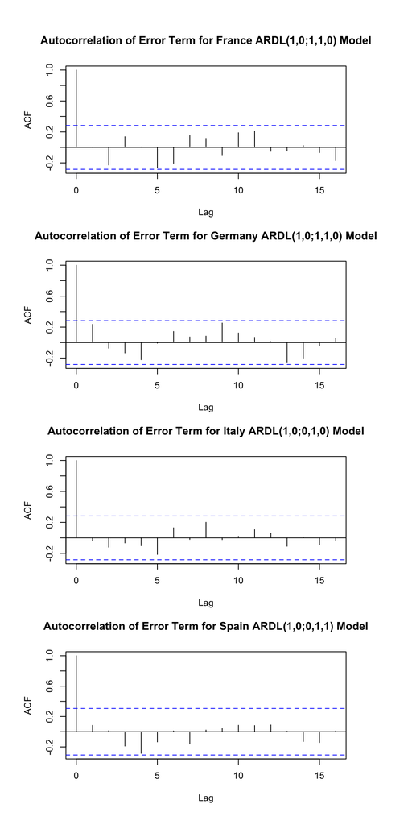

# Results

The following regression tables show the results for the models we have chosen through our modelling approach.

Goodness-of-fit statistics for France ARDL(1,0;1,1,0,0) model

| Term | Estimate | Std. Error | Test statistic | p-value |
| --- | --- | --- | --- | --- |
| (Intercept) | -0.0042 | 0.0127 | -0.3329 | 0.7408 |
| L(d(R)) | 0.6000 | 0.0949 | 6.3218 | 0.0000 |
| d(S) | -0.0051 | 0.0019 | -2.6683 | 0.0106 |
| L(d(S)) | -0.0062 | 0.0021 | -2.9315 | 0.0053 |

Goodness-of-fit statistics for Germany ARDL(1,0;1,1,0,0) model

| Term | Estimate | Std. Error | Test statistic | p-value |
| --- | --- | --- | --- | --- |
| (Intercept) | -0.0041 | 0.0094 | -0.4391 | 0.6628 |
| L(d(R)) | 0.5786 | 0.0765 | 7.5669 | 0.0000 |
| d(S) | -0.0119 | 0.0020 | -6.0739 | 0.0000 |
| L(d(S)) | -0.0059 | 0.0025 | -2.3218 | 0.0249 |

Goodness-of-fit statistics for Italy ARDL(1,0;0,1,0,0) model

| Term | Estimate | Std. Error | Test statistic | p-value |
| --- | --- | --- | --- | --- |
| (Intercept) | -0.0046 | 0.0155 | -0.2978 | 0.7672 |
| L(d(R)) | 0.6155 | 0.0985 | 6.2476 | 0.0000 |
| L(d(S)) | -0.0088 | 0.0031 | -2.8112 | 0.0073 |

Goodness-of-fit statistics for Spain ARDL(1,0;0,1,1,0) model

| Term | Estimate | Std. Error | Test statistic | p-value |
| --- | --- | --- | --- | --- |
| (Intercept) | 0.0054 | 0.0172 | 0.3166 | 0.7534 |
| L(d(R)) | 0.6878 | 0.0983 | 6.9976 | 0.0000 |
| L(d(S)) | 0.0067 | 0.0031 | 2.1616 | 0.0372 |
| L(d(S), 2) | -0.0093 | 0.0026 | -3.5661 | 0.0010 |

For all of the countries both the effect of the lagged changes in Reproduction Rate and the effect of changes in the Stringency Index at the lags chosen are statistically significant at the p<0.05-level. Now, there are several approaches through which we can interpret these models. - First, we can look at the sign of the coefficients. Does an increasing policy stringency lead to lower reproduction rates in all cases? - Second, we can look at the strength of the effects. In which country do changes in policy stringency lead to the highest impact on the reproduction rate? - Thirdly, we can look at the specific lags for the changes in the Stringency Index that produced the best model fit. What does it mean when in Germany and France lags of zero and one week of changes in the stringency index best explain changes in the Reproduction rate, while in Italy the best model fit is at a lag of one week, and in Spain the best model fit is at a lag of one and two weeks? - Fourthly, we can look at the model residuals.

The sign of the coefficients is in line with our expectations, where increases in the policy stringency, meaning e.g. more restrictive social distancing measures, lead to the deceleration of the growth in the reproduction rate, or an acceleration in the decline of the reproduction rate. However, this comes with an exception in the case of Spain, where changes towards more strict policies lead to increases in the reproduction rate in the first week after the change, and only in the second week after the change the reproduction rate is lowered as expected.

Secondly, the strength of the effects differs across the four countries, although not substantially. In France, a one point increase in the policy stringency add on average -0.0051 to the changes in the time-variable reproduction rate immediately when the changes in the policy stringency occur, and -0.0062 one week after the changes occur. Meanwhile in Germany the impact of a change in policy stringency is a little bit higher with a one point increase in the policy stringency adding -0.0119 to the changes in the reproduction rate immediately when the change occurs and -0.0059 one week after the changes. In Italy, a one point increase in the policy stringency add -0.0088 to the changes in the time-variable reproduction rate, one week after the changes occur, and in Spain a one point increase in the policy stringency first lead to an acceleration of the growth of the reproduction rate, or respectively a deceleration in its decline one week after the changes occur, with 0.0067 added to the changes, and the expected deceleration of the growth of the reproduction rate, and accceleration in its decline two weeks after the changes occur, with -0.0093 added to the changes.

Although not a very robust measure, because the differences in model fit were small in some cases and therefore we could have easily ended up with other lags, the differences in the lags of the explanatory variable that led to the optimal model fit for the four countries can be interpreted as a measure for how quickly the changes in the reproduction rate followed the changes in policy stringency. In effect, this would mean that in Germany and France, the changes in reproduction rate followed the changes in policy stringency on the heels, while in Spain, the changes in reproduction rate would only respond to changes in the policies between one or two weeks after they come into operation.

Last, but not least, and perhaps a more unconventional way to obtain model results, we can look at the model residuals.

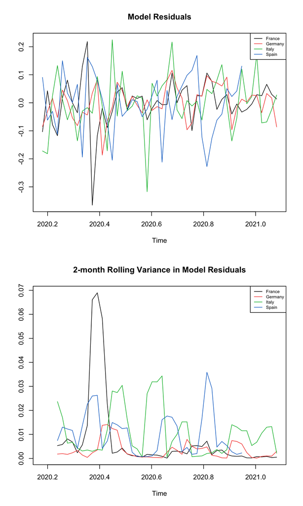

## Discussion

In Germany and France the lag in policy stringency is even smaller than what we would expect telling from the incubation period of COVID-19. A possible reason for this is that in these countries already the media and political buildup to the announcement of more restrictive measures might have led to self-imposed restrictive behaviour in the population. (see e.g. Kauermann, Küchenhoff, and Berger 2021, 14)

Explaining the comparatively higher lags in Italy and Spain, and explaining the contradictory effect of higher policy stringency in the first week after its introduction in Spain should be the subject of a more in-depth case study. However, one study by Pulejo and Querubín, who researched “the extent to which political considerations have shaped public policy at the onset of the COVID-19 epidemic,” suggests that “reelection concerns can play an important role in explaining [the] early variation in government responses, with particular regard to public health measures that can have immediate negative impact on the economy.” (Pulejo and Querubín 2021, 1) They find that “whenever the safeguard on public health is at odds with economic well-being, policymakers may decide to partially sacrifice the former for the latter.”(Pulejo and Querubín 2021, 2) Given the fact that Spain (15.4%) and Italy (10.7%) still have the highest unemployment quotas just behind Greece in the EU, with France (7.3%) being in the midfield and Germany (4.4%) having one of the lowest quotas (“Eu Unemployment Rate” 2021), it seems plausible that in Spain and Italy, policy makers were balancing their decision more towards economic well-being than this was the case in France and Germany.

Finally, in congruence with the differenced time series used in our analysis the model residuals show some heteroskedasticity. While the interpretation of our results should still hold, the existence of heteroskedasticity means we cannot realibly estimate the test statistics. For this purpose, we could either calculate heteroskedasticity and autocorrelation consistent standard errors using the Newey-West method, or we could fit an autoregressive conditional heteroskedasticity model. (Yobero 2017) Both these methods are however beyond the scope of this assignment.

## Conclusion

In this analysis we have tried to answer the question of how the epidemiological effectiveness of policy making with COVID-19-related, restrictive policies compares among France, Germany, Italy and Spain. We used the time-varying reproduction rate and the policy stringency index from the Oxford COVID-19 Government Response Tracker to show for each of these countries, how timely policy makers were able to lower the reproduction rate and how effectively they were able to lower the reproduction rate.

While we suggested some possible avenues in explaining the differences among these countries, with the most promising coming from research that asks for non-epidemiological motivations in COVID-19-related policy making, further research could be a more qualitatively-oriented, comparative case study, that connects these findings to a more in-depth view of the succession of events in each country. Eventually, this might lead to insights not only on the most effective policies in tackling a pandemic like this one, but also on what factors lead to the effective implementation of these policies.

# Bibliography

“Eu Unemployment Rate.” 2021. Statistisches Bundesamt.

Hale, Thomas, Noam Angrist, Rafael Goldszmidt, Beatriz Kira, Anna Petherick, Toby Phillips, Samuel Webster, et al. 2021. “A Global Panel Database of Pandemic Policies (Oxford COVID-19 Government Response Tracker).” *Nature Human Behaviour* 5 (4): 529–38. https://doi.org/10.1038/s41562-021-01079-8.

Kauermann, Göran, Helmut Küchenhoff, and Ursula Berger. 2021. “CODAG Bericht Nr. 16.” München: Ludwig-Maximilians-Universität.

Koh, Wee Chian, Lin Naing, and Justin Wong. 2020. “Estimating the Impact of Physical Distancing Measures in Containing COVID-19: An Empirical Analysis.” *International Journal of Infectious Diseases* 100 (November): 42–49. https://doi.org/10.1016/j.ijid.2020.08.026.

Lauer, Stephen A., Kyra H. Grantz, Qifang Bi, Forrest K. Jones, Qulu Zheng, Hannah R. Meredith, Andrew S. Azman, Nicholas G. Reich, and Justin Lessler. 2020. “The Incubation Period of Coronavirus Disease 2019 (COVID-19) From Publicly Reported Confirmed Cases: Estimation and Application.” *Annals of Internal Medicine* 172 (9): 577–82. https://doi.org/10.7326/M20-0504.

Li, You, Harry Campbell, Durga Kulkarni, Alice Harpur, Madhurima Nundy, Xin Wang, and Harish Nair. 2021. “The Temporal Association of Introducing and Lifting Non-Pharmaceutical Interventions with the Time-Varying Reproduction Number (R) of SARS-CoV-2: A Modelling Study Across 131 Countries.” *The Lancet Infectious Diseases* 21 (2): 193–202. https://doi.org/10.1016/S1473-3099(20)30785-4.

Liu, Yang, Christian Morgenstern, James Kelly, Rachel Lowe, and Mark Jit. 2021. “The Impact of Non-Pharmaceutical Interventions on SARS-CoV-2 Transmission Across 130 Countries and Territories.” *BMC Medicine* 19 (1): 40. https://doi.org/10.1186/s12916-020-01872-8.

Matteson, David S. 2021. “Time Series Analysis in R.”

Pulejo, Massimo, and Pablo Querubín. 2021. “Electoral Concerns Reduce Restrictive Measures During the COVID-19 Pandemic.” *Journal of Public Economics* 198 (June): 104387. https://doi.org/10.1016/j.jpubeco.2021.104387.

Ritchie, Hannah, Esteban Ortiz-Ospina, and Diana Beltekian. 2020. “Coronavirus Pandemic (COVID-19).” *Our World in Data*.

Rozanova, Liudmila, Alexander Temerev, and Antoine Flahault. 2020. “Comparing the Scope and Efficacy of COVID-19 Response Strategies in 16 Countries: An Overview.” *International Journal of Environmental Research and Public Health* 17 (24): 9421. https://doi.org/10.3390/ijerph17249421.

“WHO Coronavirus (COVID-19) Dashboard.” 2021. https://covid19.who.int.

Yobero, Czar. 2017. “Time Series Regression with Stationary Variables: An Introduction to the ARDL Model.” https://rpubs.com/cyobero/ardl.

# Appendix

## Model Selection

Goodness-of-fit statistics for `France` models

| Model | R squared | Test statistic | AIC | BIC |
| --- | --- | --- | --- | --- |
| ARDL(1,0;1,0,0,0) | 0.661 | 43.842 | -86.479 | -78.994 |
| ARDL(1,0;0,1,0,0) | 0.67 | 45.754 | -87.843 | -80.358 |
| ARDL(1,0;0,0,1,0) | 0.598 | 28.29 | -66.522 | -59.668 |
| ARDL(1,0;0,0,0,1) | 0.52 | 16.79 | -50.556 | -44.451 |
| ARDL(1,0;1,1,0,0) | 0.716 | 37.024 | -93.042 | -83.686 |
| ARDL(1,0;1,0,1,0) | 0.623 | 20.367 | -67.115 | -58.547 |
| ARDL(1,0;1,0,0,1) | 0.522 | 10.926 | -48.709 | -41.077 |
| ARDL(1,0;0,1,1,0) | 0.711 | 30.382 | -78.068 | -69.5 |
| ARDL(1,0;0,1,0,1) | 0.641 | 17.85 | -58.427 | -50.796 |
| ARDL(1,0;0,0,1,1) | 0.571 | 13.298 | -52.36 | -44.728 |
| ARDL(1,0;1,1,1,0) | 0.712 | 22.241 | -76.161 | -65.88 |
| ARDL(1,0;1,0,1,1) | 0.572 | 9.697 | -50.472 | -41.314 |
| ARDL(1,0;0,1,1,1) | 0.656 | 10.659 | -55.842 | -45.157 |
| ARDL(1,0;1,1,1,1) | 0.656 | 10.659 | -55.842 | -45.157 |
| ARDL(1,1;1,0,0,0) | 0.625 | 20.57 | -67.368 | -58.8 |
| ARDL(1,1;0,1,0,0) | 0.703 | 29.162 | -76.88 | -68.312 |
| ARDL(1,1;0,0,1,0) | 0.627 | 20.761 | -67.605 | -59.037 |
| ARDL(1,1;0,0,0,1) | 0.541 | 11.801 | -50.101 | -42.469 |
| ARDL(1,1;1,1,0,0) | 0.703 | 21.301 | -74.908 | -64.627 |
| ARDL(1,1;1,0,1,0) | 0.646 | 16.44 | -67.739 | -57.457 |
| ARDL(1,1;1,0,0,1) | 0.542 | 8.586 | -48.166 | -39.008 |
| ARDL(1,1;0,1,1,0) | 0.729 | 24.15 | -78.592 | -68.311 |
| ARDL(1,1;0,1,0,1) | 0.667 | 14.511 | -58.973 | -49.815 |
| ARDL(1,1;0,0,1,1) | 0.618 | 11.739 | -54.341 | -45.182 |
| ARDL(1,1;1,1,1,0) | 0.729 | 18.805 | -76.628 | -64.633 |
| ARDL(1,1;1,0,1,1) | 0.618 | 9.071 | -52.348 | -41.663 |
| ARDL(1,1;1,1,1,1) | 0.696 | 10.282 | -58.04 | -45.829 |

Goodness-of-fit statistics for `Germany` models

| Model | R squared | Test statistic | AIC | BIC |
| --- | --- | --- | --- | --- |
| ARDL(1,0;1,0,0,0) | 0.84 | 117.852 | -119.472 | -111.987 |
| ARDL(1,0;0,1,0,0) | 0.737 | 63.195 | -95.791 | -88.306 |
| ARDL(1,0;0,0,1,0) | 0.759 | 59.924 | -83.186 | -76.331 |
| ARDL(1,0;0,0,0,1) | 0.848 | 86.774 | -97.758 | -91.652 |
| ARDL(1,0;1,1,0,0) | 0.857 | 88.031 | -123.02 | -113.664 |
| ARDL(1,0;1,0,1,0) | 0.886 | 96.208 | -111.968 | -103.4 |
| ARDL(1,0;1,0,0,1) | 0.866 | 64.68 | -99.968 | -92.336 |
| ARDL(1,0;0,1,1,0) | 0.822 | 56.923 | -93.546 | -84.978 |
| ARDL(1,0;0,1,0,1) | 0.878 | 71.798 | -103.063 | -95.431 |
| ARDL(1,0;0,0,1,1) | 0.849 | 56.39 | -95.967 | -88.335 |
| ARDL(1,0;1,1,1,0) | 0.894 | 76.136 | -112.928 | -102.647 |
| ARDL(1,0;1,0,1,1) | 0.866 | 46.991 | -98.029 | -88.871 |
| ARDL(1,0;0,1,1,1) | 0.884 | 42.538 | -100.751 | -90.066 |
| ARDL(1,0;1,1,1,1) | 0.884 | 42.538 | -100.751 | -90.066 |
| ARDL(1,1;1,0,0,0) | 0.907 | 120.849 | -120.356 | -111.788 |
| ARDL(1,1;0,1,0,0) | 0.841 | 65.364 | -98.261 | -89.693 |
| ARDL(1,1;0,0,1,0) | 0.824 | 57.704 | -94.006 | -85.438 |
| ARDL(1,1;0,0,0,1) | 0.88 | 73.599 | -103.804 | -96.172 |
| ARDL(1,1;1,1,0,0) | 0.908 | 88.892 | -118.652 | -108.371 |
| ARDL(1,1;1,0,1,0) | 0.908 | 88.319 | -118.412 | -108.13 |
| ARDL(1,1;1,0,0,1) | 0.892 | 60.177 | -105.428 | -96.27 |
| ARDL(1,1;0,1,1,0) | 0.842 | 48.058 | -96.521 | -86.239 |
| ARDL(1,1;0,1,0,1) | 0.891 | 59.28 | -104.972 | -95.814 |
| ARDL(1,1;0,0,1,1) | 0.885 | 55.633 | -103.056 | -93.897 |
| ARDL(1,1;1,1,1,0) | 0.908 | 69.24 | -116.707 | -104.712 |
| ARDL(1,1;1,0,1,1) | 0.893 | 46.822 | -103.649 | -92.965 |
| ARDL(1,1;1,1,1,1) | 0.898 | 39.495 | -103.126 | -90.916 |

Goodness-of-fit statistics for `Italy` models

| Model | R squared | Test statistic | AIC | BIC |
| --- | --- | --- | --- | --- |
| ARDL(1,0;1,0,0,0) | 0.497 | 22.192 | -70.423 | -62.938 |
| ARDL(1,0;0,1,0,0) | 0.552 | 27.777 | -76.075 | -68.59 |
| ARDL(1,0;0,0,1,0) | 0.507 | 19.543 | -64.498 | -57.643 |
| ARDL(1,0;0,0,0,1) | 0.535 | 17.803 | -68.981 | -62.876 |
| ARDL(1,0;1,1,0,0) | 0.556 | 18.358 | -74.442 | -65.086 |
| ARDL(1,0;1,0,1,0) | 0.507 | 12.688 | -62.5 | -53.932 |
| ARDL(1,0;1,0,0,1) | 0.54 | 11.728 | -67.362 | -59.73 |
| ARDL(1,0;0,1,1,0) | 0.552 | 15.191 | -66.41 | -57.843 |
| ARDL(1,0;0,1,0,1) | 0.551 | 12.261 | -68.186 | -60.554 |
| ARDL(1,0;0,0,1,1) | 0.543 | 11.881 | -67.601 | -59.969 |
| ARDL(1,0;1,1,1,0) | 0.552 | 11.111 | -64.463 | -54.182 |
| ARDL(1,0;1,0,1,1) | 0.552 | 8.936 | -66.284 | -57.126 |
| ARDL(1,0;0,1,1,1) | 0.569 | 7.38 | -65.56 | -54.876 |
| ARDL(1,0;1,1,1,1) | 0.569 | 7.38 | -65.56 | -54.876 |
| ARDL(1,1;1,0,0,0) | 0.46 | 10.494 | -58.738 | -50.17 |
| ARDL(1,1;0,1,0,0) | 0.526 | 13.706 | -64.136 | -55.568 |
| ARDL(1,1;0,0,1,0) | 0.514 | 13.044 | -63.08 | -54.512 |
| ARDL(1,1;0,0,0,1) | 0.535 | 11.494 | -66.993 | -59.361 |
| ARDL(1,1;1,1,0,0) | 0.527 | 10.03 | -62.197 | -51.915 |
| ARDL(1,1;1,0,1,0) | 0.514 | 9.522 | -61.087 | -50.806 |
| ARDL(1,1;1,0,0,1) | 0.54 | 8.512 | -65.381 | -56.223 |
| ARDL(1,1;0,1,1,0) | 0.559 | 11.386 | -65.019 | -54.737 |
| ARDL(1,1;0,1,0,1) | 0.551 | 8.89 | -66.188 | -57.03 |
| ARDL(1,1;0,0,1,1) | 0.543 | 8.624 | -65.622 | -56.464 |
| ARDL(1,1;1,1,1,0) | 0.559 | 8.87 | -63.056 | -51.061 |
| ARDL(1,1;1,0,1,1) | 0.553 | 6.916 | -64.321 | -53.637 |
| ARDL(1,1;1,1,1,1) | 0.569 | 5.936 | -63.577 | -51.366 |

Goodness-of-fit statistics for `Spain` models

| Model | R squared | Test statistic | AIC | BIC |
| --- | --- | --- | --- | --- |
| ARDL(1,0;1,0,0,0) | 0.599 | 33.677 | -56.91 | -49.425 |
| ARDL(1,0;0,1,0,0) | 0.539 | 26.315 | -50.167 | -42.682 |
| ARDL(1,0;0,0,1,0) | 0.664 | 37.629 | -58.516 | -51.662 |
| ARDL(1,0;0,0,0,1) | 0.662 | 30.341 | -48.265 | -42.16 |
| ARDL(1,0;1,1,0,0) | 0.6 | 21.965 | -54.927 | -45.571 |
| ARDL(1,0;1,0,1,0) | 0.665 | 24.432 | -56.523 | -47.955 |
| ARDL(1,0;1,0,0,1) | 0.667 | 20.054 | -46.811 | -39.179 |
| ARDL(1,0;0,1,1,0) | 0.702 | 29.068 | -61.392 | -52.824 |
| ARDL(1,0;0,1,0,1) | 0.691 | 22.404 | -49.371 | -41.74 |
| ARDL(1,0;0,0,1,1) | 0.73 | 26.975 | -53.858 | -46.226 |
| ARDL(1,0;1,1,1,0) | 0.702 | 21.25 | -59.443 | -49.162 |
| ARDL(1,0;1,0,1,1) | 0.741 | 20.726 | -53.309 | -44.151 |
| ARDL(1,0;0,1,1,1) | 0.772 | 18.913 | -55.596 | -44.911 |
| ARDL(1,0;1,1,1,1) | 0.772 | 18.913 | -55.596 | -44.911 |
| ARDL(1,1;1,0,0,0) | 0.6 | 18.474 | -49.273 | -40.706 |
| ARDL(1,1;0,1,0,0) | 0.602 | 18.687 | -49.557 | -40.989 |
| ARDL(1,1;0,0,1,0) | 0.67 | 25.062 | -57.219 | -48.651 |
| ARDL(1,1;0,0,0,1) | 0.664 | 19.786 | -46.507 | -38.875 |
| ARDL(1,1;1,1,0,0) | 0.609 | 14 | -48.21 | -37.928 |
| ARDL(1,1;1,0,1,0) | 0.67 | 18.298 | -55.234 | -44.953 |
| ARDL(1,1;1,0,0,1) | 0.668 | 14.59 | -44.89 | -35.732 |
| ARDL(1,1;0,1,1,0) | 0.718 | 22.922 | -61.649 | -51.368 |
| ARDL(1,1;0,1,0,1) | 0.692 | 16.322 | -47.485 | -38.327 |
| ARDL(1,1;0,0,1,1) | 0.752 | 21.979 | -54.8 | -45.641 |
| ARDL(1,1;1,1,1,0) | 0.721 | 18.117 | -60.124 | -48.129 |
| ARDL(1,1;1,0,1,1) | 0.756 | 17.39 | -53.415 | -42.731 |
| ARDL(1,1;1,1,1,1) | 0.791 | 16.99 | -56.557 | -44.346 |

## Code

```r
# Adding Policy Stringency Data

#policy_data <- read.csv(url("https://raw.githubusercontent.com/OxCGRT/covid-policy-tracker/master/data/OxCGRT_latest.csv"))

policy_data <- read.csv("PolicyData.csv")

# coerce Date column to date format
policy_data$Date = as.Date(as.character(policy_data$Date), format = "%Y%m%d")

# create dataframe with only national level data
policy_data <- policy_data %>% filter(Jurisdiction == "NAT_TOTAL")

# select countries
policy_data <- policy_data %>% filter(CountryCode == "DEU" |
                                       CountryCode == "ITA" |
                                       CountryCode == "FRA" |
                                       CountryCode == "ESP")

# only selecting the columns that are interesting
policy_data <- policy_data %>% select(Date, CountryName, StringencyIndex)

# Adding the Data on Reproduction Rate

#cases_data <- read.csv(url("https://covid.ourworldindata.org/data/owid-covid-data.csv"))

cases_data <- read.csv("CasesData.csv")

# select countries and columns of interest
cases_data <- cases_data %>% filter(location == "France" |
                                    location == "Italy" |
                                    location == "Germany" |
                                    location == "Spain") %>%
                             select(location, date, reproduction_rate) %>%
                             rename(CountryName = location,
                                    Date = date,
                                    ReproductionRate = reproduction_rate)

# coercing to date format
cases_data$Date <- as.Date(as.character(cases_data$Date), format = "%Y-%m-%d")

# merging policy stringency and reproduction rate data on date and country
data <- policy_data %>%
  full_join(cases_data, by = c("Date", "CountryName"))

# restricting the date range
data <- data %>% filter(Date >= as.Date("2020-03-03") & Date < as.Date("2021-03-25")) %>% drop_na()

# Make Daily Data Weekly

# extract day of the week (saturday = 6)
data$Week_Day <- as.numeric(format(data$Date, format='%w'))

# adjust end-of-week date (first saturday from the original date)
data$End_of_Week <- data$Date + (6 - data$Week_Day)

# aggregate over week and country
Stringency_weekly <- aggregate(StringencyIndex~End_of_Week+CountryName, FUN=mean, data=data, na.rm=TRUE)
ReproductionRate_weekly <- aggregate(ReproductionRate~End_of_Week+CountryName, FUN=mean, data=data, na.rm=TRUE)

# merge weekly data
data_weekly <- Stringency_weekly %>%
  full_join(ReproductionRate_weekly, by = c("End_of_Week", "CountryName")) %>%
  rename(Date = End_of_Week)

# Creating Subsets for Countries

France <- data_weekly %>%
  filter(CountryName == "France") %>%
  rename(R = ReproductionRate, S = StringencyIndex)
Italy <- data_weekly %>%
  filter(CountryName == "Italy") %>%
  rename(R = ReproductionRate, S = StringencyIndex)
Germany <- data_weekly %>%
  filter(CountryName == "Germany") %>%
  rename(R = ReproductionRate, S = StringencyIndex)
Spain <- data_weekly %>%
  filter(CountryName == "Spain") %>%
  rename(R = ReproductionRate, S = StringencyIndex)

# Convert to Time Series Objects
France.ts <- ts(France[,c("S", "R")], freq=365.25/7, start=decimal_date(ymd("2020-03-07")))
Germany.ts <- ts(Germany[,c("S", "R")], freq=365.25/7, start=decimal_date(ymd("2020-03-07")))
Italy.ts <- ts(Italy[,c("S", "R")], freq=365.25/7, start=decimal_date(ymd("2020-03-07")))
Spain.ts <- ts(Spain[,c("S", "R")], freq=365.25/7, start=decimal_date(ymd("2020-03-07")))

# Plot Time Series for France
par(mfrow = c(2,1), cex = 0.8, mar = c(2, 4, 2, 4), oma = c(2, 2, 2, 2))
plot(France.ts[,"R"], ylab="Reproduction Rate", main = "Time Series for Reproduction Rate and Stringency Index in France", cex.main = 0.9)
plot(France.ts[,"S"], ylab="Stringency Index")

# Scatter Plot on Autocorrelation for Reproduction Rate in France
par(mfrow = c(2,1), cex = 0.8, mar = c(4, 4, 2, 4), oma = c(2, 2, 2, 2))

rrL1 <- data.frame(cbind(France[,"R"], lag(France[,"R"],1)))
names(rrL1) <- c("R","RL1")
plot(rrL1, ylab = "Reproduction Rate at Lag 1", xlab = "Reproduction Rate",
     main = "Autocorrelation for Reproduction Rate at Lag 1 and 2", cex.main = 0.9)
meanR <- mean(rrL1$R, na.rm=TRUE)
abline(v=meanR, lty=2)
abline(h=mean(rrL1$RL1, na.rm=TRUE), lty=2)


rrL2 <- data.frame(cbind(France[,"R"], lag(France[,"R"],2)))
names(rrL2) <- c("R","RL2")
plot(rrL2, ylab = "Reproduction Rate at Lag 2", xlab = "Reproduction Rate")
meanR <- mean(rrL2$R, na.rm=TRUE)
abline(v=meanR, lty=2)
abline(h=mean(rrL2$RL2, na.rm=TRUE), lty=2)

# Plot Autocorrelation Function for Reproduction Rate and Stringency Index for France
par(mfrow = c(2,1), cex = 0.8, mar = c(4, 4, 4, 4), oma = c(2, 2, 2, 2))
acf(France.ts[1:nrow(France.ts), "R"], main = "Autocorrelation for Reproduction Rate for France", cex.main = 0.9)
acf(France.ts[1:nrow(France.ts), "S"], main = "Autocorrelation for Stringency Index for France")

# Plot First Difference of Time Series for France
par(mfrow = c(2,1), cex = 0.8, mar = c(4, 4, 4, 4), oma = c(2, 2, 2, 2))
plot(diff(France.ts[,"R"]), main = "First difference of Reproduction Rate for France", ylab = "diff(Reproduction Rate)")
plot(diff(France.ts[,"S"]), main ="First difference of Stringency Index for France", ylab = "diff(Stringency Index)")

# Plot Autocorrelation Function for Differenced Time Series
par(mfrow = c(2,1), cex = 0.8, mar = c(4, 4, 4, 4), oma = c(2, 2, 2, 2))
acf(diff(France.ts[1:nrow(France.ts), "R"]), main = "Autocorrelation for First Difference of Reproduction Rate for France", cex.main = 0.9)
acf(diff(France.ts[1:nrow(France.ts), "S"]), main = "Autocorrelation for First Difference of Stringency Index for France")

# Specify the Models

# France
ARDL101000France.dyn <- dynlm(d(R) ~ L(d(R)) + d(S), data=France.ts)
ARDL100100France.dyn <- dynlm(d(R) ~ L(d(R)) + L(d(S)), data=France.ts)
ARDL100010France.dyn <- dynlm(d(R) ~ L(d(R)) + L(d(S),2), data=France.ts)
ARDL100001France.dyn <- dynlm(d(R) ~ L(d(R)) + L(d(S),3), data=France.ts)
ARDL101100France.dyn <- dynlm(d(R) ~ L(d(R)) + d(S) + L(d(S)), data=France.ts)
ARDL101010France.dyn <- dynlm(d(R) ~ L(d(R)) + d(S) + L(d(S),2), data=France.ts)
ARDL101001France.dyn <- dynlm(d(R) ~ L(d(R)) + d(S) + L(d(S),3), data=France.ts)
ARDL100110France.dyn <- dynlm(d(R) ~ L(d(R)) + L(d(S)) + L(d(S),2), data=France.ts)
ARDL100101France.dyn <- dynlm(d(R) ~ L(d(R)) + L(d(S)) + L(d(S),3), data=France.ts)
ARDL100011France.dyn <- dynlm(d(R) ~ L(d(R)) + L(d(S),2) + L(d(S),3), data=France.ts)
ARDL101110France.dyn <- dynlm(d(R) ~ L(d(R)) + d(S) + L(d(S)) + L(d(S),2), data=France.ts)
ARDL101011France.dyn <- dynlm(d(R) ~ L(d(R)) + d(S) + L(d(S),2) + L(d(S),3), data=France.ts)
ARDL100111France.dyn <- dynlm(d(R) ~ L(d(R)) + d(S) + + L(d(S), 1) + L(d(S),2) + L(d(S),3), data=France.ts)
ARDL101111France.dyn <- dynlm(d(R) ~ L(d(R)) + d(S) + + L(d(S)) + L(d(S),2) + L(d(S),3), data=France.ts)
ARDL111000France.dyn <- dynlm(d(R) ~ L(d(R)) + L(d(R),2) + d(S), data=France.ts)
ARDL110100France.dyn <- dynlm(d(R) ~ L(d(R)) + L(d(R),2) + L(d(S)), data=France.ts)
ARDL110010France.dyn <- dynlm(d(R) ~ L(d(R)) + L(d(R),2) + L(d(S),2), data=France.ts)
ARDL110001France.dyn <- dynlm(d(R) ~ L(d(R)) + L(d(R),2) + L(d(S),3), data=France.ts)
ARDL111100France.dyn <- dynlm(d(R) ~ L(d(R)) + L(d(R),2) + d(S) + L(d(S)), data=France.ts)
ARDL111010France.dyn <- dynlm(d(R) ~ L(d(R)) + L(d(R),2) + d(S) + L(d(S),2), data=France.ts)
ARDL111001France.dyn <- dynlm(d(R) ~ L(d(R)) + L(d(R),2) + d(S) + L(d(S),3), data=France.ts)
ARDL110110France.dyn <- dynlm(d(R) ~ L(d(R)) + L(d(R),2) + L(d(S)) + L(d(S),2), data=France.ts)
ARDL110101France.dyn <- dynlm(d(R) ~ L(d(R)) + L(d(R),2) + L(d(S)) + L(d(S),3), data=France.ts)
ARDL110011France.dyn <- dynlm(d(R) ~ L(d(R)) + L(d(R),2) + L(d(S),2) + L(d(S),3), data=France.ts)
ARDL111110France.dyn <- dynlm(d(R) ~ L(d(R)) + L(d(R),2) + d(S) + L(d(S)) + L(d(S),2), data=France.ts)
ARDL111011France.dyn <- dynlm(d(R) ~ L(d(R)) + L(d(R),2) + d(S) + L(d(S),2) + L(d(S),3), data=France.ts)
ARDL111111France.dyn <- dynlm(d(R) ~ L(d(R)) + L(d(R),2) + d(S) + L(d(S)) + L(d(S),2) + L(d(S),3), data=France.ts)
```

```r
# Germany
ARDL101000Germany.dyn <- dynlm(d(R) ~ L(d(R)) + d(S), data=Germany.ts)
ARDL100100Germany.dyn <- dynlm(d(R) ~ L(d(R)) + L(d(S)), data=Germany.ts)
ARDL100010Germany.dyn <- dynlm(d(R) ~ L(d(R)) + L(d(S),2), data=Germany.ts)
ARDL100001Germany.dyn <- dynlm(d(R) ~ L(d(R)) + L(d(S),3), data=Germany.ts)
ARDL101100Germany.dyn <- dynlm(d(R) ~ L(d(R)) + d(S) + L(d(S)), data=Germany.ts)
ARDL101010Germany.dyn <- dynlm(d(R) ~ L(d(R)) + d(S) + L(d(S),2), data=Germany.ts)
ARDL101001Germany.dyn <- dynlm(d(R) ~ L(d(R)) + d(S) + L(d(S),3), data=Germany.ts)
ARDL100110Germany.dyn <- dynlm(d(R) ~ L(d(R)) + L(d(S)) + L(d(S),2), data=Germany.ts)
ARDL100101Germany.dyn <- dynlm(d(R) ~ L(d(R)) + L(d(S)) + L(d(S),3), data=Germany.ts)
ARDL100011Germany.dyn <- dynlm(d(R) ~ L(d(R)) + L(d(S),2) + L(d(S),3), data=Germany.ts)
ARDL101110Germany.dyn <- dynlm(d(R) ~ L(d(R)) + d(S) + L(d(S)) + L(d(S),2), data=Germany.ts)
ARDL101011Germany.dyn <- dynlm(d(R) ~ L(d(R)) + d(S) + L(d(S),2) + L(d(S),3), data=Germany.ts)
ARDL100111Germany.dyn <- dynlm(d(R) ~ L(d(R)) + d(S) + + L(d(S), 1) + L(d(S),2) + L(d(S),3), data=Germany.ts)
ARDL101111Germany.dyn <- dynlm(d(R) ~ L(d(R)) + d(S) + + L(d(S)) + L(d(S),2) + L(d(S),3), data=Germany.ts)
ARDL111000Germany.dyn <- dynlm(d(R) ~ L(d(R)) + L(d(R),2) + d(S), data=Germany.ts)
ARDL110100Germany.dyn <- dynlm(d(R) ~ L(d(R)) + L(d(R),2) + L(d(S)), data=Germany.ts)
ARDL110010Germany.dyn <- dynlm(d(R) ~ L(d(R)) + L(d(R),2) + L(d(S),2), data=Germany.ts)
ARDL110001Germany.dyn <- dynlm(d(R) ~ L(d(R)) + L(d(R),2) + L(d(S),3), data=Germany.ts)
ARDL111100Germany.dyn <- dynlm(d(R) ~ L(d(R)) + L(d(R),2) + d(S) + L(d(S)), data=Germany.ts)
ARDL111010Germany.dyn <- dynlm(d(R) ~ L(d(R)) + L(d(R),2) + d(S) + L(d(S),2), data=Germany.ts)
ARDL111001Germany.dyn <- dynlm(d(R) ~ L(d(R)) + L(d(R),2) + d(S) + L(d(S),3), data=Germany.ts)
ARDL110110Germany.dyn <- dynlm(d(R) ~ L(d(R)) + L(d(R),2) + L(d(S)) + L(d(S),2), data=Germany.ts)
ARDL110101Germany.dyn <- dynlm(d(R) ~ L(d(R)) + L(d(R),2) + L(d(S)) + L(d(S),3), data=Germany.ts)
ARDL110011Germany.dyn <- dynlm(d(R) ~ L(d(R)) + L(d(R),2) + L(d(S),2) + L(d(S),3), data=Germany.ts)
ARDL111110Germany.dyn <- dynlm(d(R) ~ L(d(R)) + L(d(R),2) + d(S) + L(d(S)) + L(d(S),2), data=Germany.ts)
ARDL111011Germany.dyn <- dynlm(d(R) ~ L(d(R)) + L(d(R),2) + d(S) + L(d(S),2) + L(d(S),3), data=Germany.ts)
ARDL111111Germany.dyn <- dynlm(d(R) ~ L(d(R)) + L(d(R),2) + d(S) + L(d(S)) + L(d(S),2) + L(d(S),3), data=Germany.ts)

# Italy
ARDL101000Italy.dyn <- dynlm(d(R) ~ L(d(R)) + d(S), data=Italy.ts)
ARDL100100Italy.dyn <- dynlm(d(R) ~ L(d(R)) + L(d(S)), data=Italy.ts)
ARDL100010Italy.dyn <- dynlm(d(R) ~ L(d(R)) + L(d(S),2), data=Italy.ts)
ARDL100001Italy.dyn <- dynlm(d(R) ~ L(d(R)) + L(d(S),3), data=Italy.ts)
ARDL101100Italy.dyn <- dynlm(d(R) ~ L(d(R)) + d(S) + L(d(S)), data=Italy.ts)
ARDL101010Italy.dyn <- dynlm(d(R) ~ L(d(R)) + d(S) + L(d(S),2), data=Italy.ts)
ARDL101001Italy.dyn <- dynlm(d(R) ~ L(d(R)) + d(S) + L(d(S),3), data=Italy.ts)
ARDL100110Italy.dyn <- dynlm(d(R) ~ L(d(R)) + L(d(S)) + L(d(S),2), data=Italy.ts)
ARDL100101Italy.dyn <- dynlm(d(R) ~ L(d(R)) + L(d(S)) + L(d(S),3), data=Italy.ts)
ARDL100011Italy.dyn <- dynlm(d(R) ~ L(d(R)) + L(d(S),2) + L(d(S),3), data=Italy.ts)
ARDL101110Italy.dyn <- dynlm(d(R) ~ L(d(R)) + d(S) + L(d(S)) + L(d(S),2), data=Italy.ts)
ARDL101011Italy.dyn <- dynlm(d(R) ~ L(d(R)) + d(S) + L(d(S),2) + L(d(S),3), data=Italy.ts)
ARDL100111Italy.dyn <- dynlm(d(R) ~ L(d(R)) + d(S) + + L(d(S), 1) + L(d(S),2) + L(d(S),3), data=Italy.ts)
ARDL101111Italy.dyn <- dynlm(d(R) ~ L(d(R)) + d(S) + + L(d(S)) + L(d(S),2) + L(d(S),3), data=Italy.ts)
ARDL111000Italy.dyn <- dynlm(d(R) ~ L(d(R)) + L(d(R),2) + d(S), data=Italy.ts)
ARDL110100Italy.dyn <- dynlm(d(R) ~ L(d(R)) + L(d(R),2) + L(d(S)), data=Italy.ts)
ARDL110010Italy.dyn <- dynlm(d(R) ~ L(d(R)) + L(d(R),2) + L(d(S),2), data=Italy.ts)
ARDL110001Italy.dyn <- dynlm(d(R) ~ L(d(R)) + L(d(R),2) + L(d(S),3), data=Italy.ts)
ARDL111100Italy.dyn <- dynlm(d(R) ~ L(d(R)) + L(d(R),2) + d(S) + L(d(S)), data=Italy.ts)
ARDL111010Italy.dyn <- dynlm(d(R) ~ L(d(R)) + L(d(R),2) + d(S) + L(d(S),2), data=Italy.ts)
ARDL111001Italy.dyn <- dynlm(d(R) ~ L(d(R)) + L(d(R),2) + d(S) + L(d(S),3), data=Italy.ts)
ARDL110110Italy.dyn <- dynlm(d(R) ~ L(d(R)) + L(d(R),2) + L(d(S)) + L(d(S),2), data=Italy.ts)
ARDL110101Italy.dyn <- dynlm(d(R) ~ L(d(R)) + L(d(R),2) + L(d(S)) + L(d(S),3), data=Italy.ts)
ARDL110011Italy.dyn <- dynlm(d(R) ~ L(d(R)) + L(d(R),2) + L(d(S),2) + L(d(S),3), data=Italy.ts)
ARDL111110Italy.dyn <- dynlm(d(R) ~ L(d(R)) + L(d(R),2) + d(S) + L(d(S)) + L(d(S),2), data=Italy.ts)
ARDL111011Italy.dyn <- dynlm(d(R) ~ L(d(R)) + L(d(R),2) + d(S) + L(d(S),2) + L(d(S),3), data=Italy.ts)
ARDL111111Italy.dyn <- dynlm(d(R) ~ L(d(R)) + L(d(R),2) + d(S) + L(d(S)) + L(d(S),2) + L(d(S),3), data=Italy.ts)

# Spain
ARDL101000Spain.dyn <- dynlm(d(R) ~ L(d(R)) + d(S), data=Spain.ts)
ARDL100100Spain.dyn <- dynlm(d(R) ~ L(d(R)) + L(d(S)), data=Spain.ts)
ARDL100010Spain.dyn <- dynlm(d(R) ~ L(d(R)) + L(d(S),2), data=Spain.ts)
ARDL100001Spain.dyn <- dynlm(d(R) ~ L(d(R)) + L(d(S),3), data=Spain.ts)
ARDL101100Spain.dyn <- dynlm(d(R) ~ L(d(R)) + d(S) + L(d(S)), data=Spain.ts)
ARDL101010Spain.dyn <- dynlm(d(R) ~ L(d(R)) + d(S) + L(d(S),2), data=Spain.ts)
ARDL101001Spain.dyn <- dynlm(d(R) ~ L(d(R)) + d(S) + L(d(S),3), data=Spain.ts)
ARDL100110Spain.dyn <- dynlm(d(R) ~ L(d(R)) + L(d(S)) + L(d(S),2), data=Spain.ts)
ARDL100101Spain.dyn <- dynlm(d(R) ~ L(d(R)) + L(d(S)) + L(d(S),3), data=Spain.ts)
ARDL100011Spain.dyn <- dynlm(d(R) ~ L(d(R)) + L(d(S),2) + L(d(S),3), data=Spain.ts)
ARDL101110Spain.dyn <- dynlm(d(R) ~ L(d(R)) + d(S) + L(d(S)) + L(d(S),2), data=Spain.ts)
ARDL101011Spain.dyn <- dynlm(d(R) ~ L(d(R)) + d(S) + L(d(S),2) + L(d(S),3), data=Spain.ts)
ARDL100111Spain.dyn <- dynlm(d(R) ~ L(d(R)) + d(S) + + L(d(S), 1) + L(d(S),2) + L(d(S),3), data=Spain.ts)
ARDL101111Spain.dyn <- dynlm(d(R) ~ L(d(R)) + d(S) + + L(d(S)) + L(d(S),2) + L(d(S),3), data=Spain.ts)
ARDL111000Spain.dyn <- dynlm(d(R) ~ L(d(R)) + L(d(R),2) + d(S), data=Spain.ts)
ARDL110100Spain.dyn <- dynlm(d(R) ~ L(d(R)) + L(d(R),2) + L(d(S)), data=Spain.ts)
ARDL110010Spain.dyn <- dynlm(d(R) ~ L(d(R)) + L(d(R),2) + L(d(S),2), data=Spain.ts)
ARDL110001Spain.dyn <- dynlm(d(R) ~ L(d(R)) + L(d(R),2) + L(d(S),3), data=Spain.ts)
ARDL111100Spain.dyn <- dynlm(d(R) ~ L(d(R)) + L(d(R),2) + d(S) + L(d(S)), data=Spain.ts)
ARDL111010Spain.dyn <- dynlm(d(R) ~ L(d(R)) + L(d(R),2) + d(S) + L(d(S),2), data=Spain.ts)
ARDL111001Spain.dyn <- dynlm(d(R) ~ L(d(R)) + L(d(R),2) + d(S) + L(d(S),3), data=Spain.ts)
ARDL110110Spain.dyn <- dynlm(d(R) ~ L(d(R)) + L(d(R),2) + L(d(S)) + L(d(S),2), data=Spain.ts)
ARDL110101Spain.dyn <- dynlm(d(R) ~ L(d(R)) + L(d(R),2) + L(d(S)) + L(d(S),3), data=Spain.ts)
ARDL110011Spain.dyn <- dynlm(d(R) ~ L(d(R)) + L(d(R),2) + L(d(S),2) + L(d(S),3), data=Spain.ts)
ARDL111110Spain.dyn <- dynlm(d(R) ~ L(d(R)) + L(d(R),2) + d(S) + L(d(S)) + L(d(S),2), data=Spain.ts)
ARDL111011Spain.dyn <- dynlm(d(R) ~ L(d(R)) + L(d(R),2) + d(S) + L(d(S),2) + L(d(S),3), data=Spain.ts)
ARDL111111Spain.dyn <- dynlm(d(R) ~ L(d(R)) + L(d(R),2) + d(S) + L(d(S)) + L(d(S),2) + L(d(S),3), data=Spain.ts)
```

```r
# Getting Test Statistics for Models
# France
glARDL101000France.dyn <- glance(ARDL101000France.dyn)[c("r.squared", "statistic", "AIC", "BIC")]
glARDL100100France.dyn <- glance(ARDL100100France.dyn)[c("r.squared", "statistic", "AIC", "BIC")]
glARDL100010France.dyn <- glance(ARDL100010France.dyn)[c("r.squared", "statistic", "AIC", "BIC")]
glARDL100001France.dyn <- glance(ARDL100001France.dyn)[c("r.squared", "statistic", "AIC", "BIC")]
glARDL101100France.dyn <- glance(ARDL101100France.dyn)[c("r.squared", "statistic", "AIC", "BIC")]
glARDL101010France.dyn <- glance(ARDL101010France.dyn)[c("r.squared", "statistic", "AIC", "BIC")]
glARDL101001France.dyn <- glance(ARDL101001France.dyn)[c("r.squared", "statistic", "AIC", "BIC")]
glARDL100110France.dyn <- glance(ARDL100110France.dyn)[c("r.squared", "statistic", "AIC", "BIC")]
glARDL100101France.dyn <- glance(ARDL100101France.dyn)[c("r.squared", "statistic", "AIC", "BIC")]
glARDL100011France.dyn <- glance(ARDL100011France.dyn)[c("r.squared", "statistic", "AIC", "BIC")]
glARDL101110France.dyn <- glance(ARDL101110France.dyn)[c("r.squared", "statistic", "AIC", "BIC")]
glARDL101011France.dyn <- glance(ARDL101011France.dyn)[c("r.squared", "statistic", "AIC", "BIC")]
glARDL100111France.dyn <- glance(ARDL100111France.dyn)[c("r.squared", "statistic", "AIC", "BIC")]
glARDL101111France.dyn <- glance(ARDL101111France.dyn)[c("r.squared", "statistic", "AIC", "BIC")]
glARDL111000France.dyn <- glance(ARDL111000France.dyn)[c("r.squared", "statistic", "AIC", "BIC")]
glARDL110100France.dyn <- glance(ARDL110100France.dyn)[c("r.squared", "statistic", "AIC", "BIC")]
glARDL110010France.dyn <- glance(ARDL110010France.dyn)[c("r.squared", "statistic", "AIC", "BIC")]
glARDL110001France.dyn <- glance(ARDL110001France.dyn)[c("r.squared", "statistic", "AIC", "BIC")]
glARDL111100France.dyn <- glance(ARDL111100France.dyn)[c("r.squared", "statistic", "AIC", "BIC")]
glARDL111010France.dyn <- glance(ARDL111010France.dyn)[c("r.squared", "statistic", "AIC", "BIC")]
glARDL111001France.dyn <- glance(ARDL111001France.dyn)[c("r.squared", "statistic", "AIC", "BIC")]
glARDL110110France.dyn <- glance(ARDL110110France.dyn)[c("r.squared", "statistic", "AIC", "BIC")]
glARDL110101France.dyn <- glance(ARDL110101France.dyn)[c("r.squared", "statistic", "AIC", "BIC")]
glARDL110011France.dyn <- glance(ARDL110011France.dyn)[c("r.squared", "statistic", "AIC", "BIC")]
glARDL111110France.dyn <- glance(ARDL111110France.dyn)[c("r.squared", "statistic", "AIC", "BIC")]
glARDL111011France.dyn <- glance(ARDL111011France.dyn)[c("r.squared", "statistic", "AIC", "BIC")]
glARDL111111France.dyn <- glance(ARDL111111France.dyn)[c("r.squared", "statistic", "AIC", "BIC")]


tabl_France <- rbind(as.numeric(glARDL101000France.dyn),
                     as.numeric(glARDL100100France.dyn),
                     as.numeric(glARDL100010France.dyn),
                     as.numeric(glARDL100001France.dyn),
                     as.numeric(glARDL101100France.dyn),
                     as.numeric(glARDL101010France.dyn),
                     as.numeric(glARDL101001France.dyn),
                     as.numeric(glARDL100110France.dyn),
                     as.numeric(glARDL100101France.dyn),
                     as.numeric(glARDL100011France.dyn),
                     as.numeric(glARDL101110France.dyn),
                     as.numeric(glARDL101011France.dyn),
                     as.numeric(glARDL100111France.dyn),
                     as.numeric(glARDL101111France.dyn),
                     as.numeric(glARDL111000France.dyn),
                     as.numeric(glARDL110100France.dyn),
                     as.numeric(glARDL110010France.dyn),
                     as.numeric(glARDL110001France.dyn),
                     as.numeric(glARDL111100France.dyn),
                     as.numeric(glARDL111010France.dyn),
                     as.numeric(glARDL111001France.dyn),
                     as.numeric(glARDL110110France.dyn),
                     as.numeric(glARDL110101France.dyn),
                     as.numeric(glARDL110011France.dyn),
                     as.numeric(glARDL111110France.dyn),
                     as.numeric(glARDL111011France.dyn),
                     as.numeric(glARDL111111France.dyn))

tabl_France <- round(tabl_France, 3)

tabl_France <- cbind(c("ARDL(1,0;1,0,0,0)",
                       "ARDL(1,0;0,1,0,0)",
                       "ARDL(1,0;0,0,1,0)",
                       "ARDL(1,0;0,0,0,1)",
                       "ARDL(1,0;1,1,0,0)",
                       "ARDL(1,0;1,0,1,0)",
                       "ARDL(1,0;1,0,0,1)",
                       "ARDL(1,0;0,1,1,0)",
                       "ARDL(1,0;0,1,0,1)",
                       "ARDL(1,0;0,0,1,1)",
                       "ARDL(1,0;1,1,1,0)",
                       "ARDL(1,0;1,0,1,1)",
                       "ARDL(1,0;0,1,1,1)",
                       "ARDL(1,0;1,1,1,1)",
                       "ARDL(1,1;1,0,0,0)",
                       "ARDL(1,1;0,1,0,0)",
                       "ARDL(1,1;0,0,1,0)",
                       "ARDL(1,1;0,0,0,1)",
                       "ARDL(1,1;1,1,0,0)",
                       "ARDL(1,1;1,0,1,0)",
                       "ARDL(1,1;1,0,0,1)",
                       "ARDL(1,1;0,1,1,0)",
                       "ARDL(1,1;0,1,0,1)",
                       "ARDL(1,1;0,0,1,1)",
                       "ARDL(1,1;1,1,1,0)",
                       "ARDL(1,1;1,0,1,1)",
                       "ARDL(1,1;1,1,1,1)"), tabl_France)

colnames(tabl_France) <- c("Model","R squared", "Test statistic", "AIC", "BIC")

tabl_France %>%
  kbl(caption="Goodness-of-fit statistics for `France` models") %>%
  kable_styling() %>%
  row_spec(5, background = "yellow")

# Germany
glARDL101000Germany.dyn <- glance(ARDL101000Germany.dyn)[c("r.squared", "statistic", "AIC", "BIC")]
glARDL100100Germany.dyn <- glance(ARDL100100Germany.dyn)[c("r.squared", "statistic", "AIC", "BIC")]
glARDL100010Germany.dyn <- glance(ARDL100010Germany.dyn)[c("r.squared", "statistic", "AIC", "BIC")]
glARDL100001Germany.dyn <- glance(ARDL100001Germany.dyn)[c("r.squared", "statistic", "AIC", "BIC")]
glARDL101100Germany.dyn <- glance(ARDL101100Germany.dyn)[c("r.squared", "statistic", "AIC", "BIC")]
glARDL101010Germany.dyn <- glance(ARDL101010Germany.dyn)[c("r.squared", "statistic", "AIC", "BIC")]
glARDL101001Germany.dyn <- glance(ARDL101001Germany.dyn)[c("r.squared", "statistic", "AIC", "BIC")]
glARDL100110Germany.dyn <- glance(ARDL100110Germany.dyn)[c("r.squared", "statistic", "AIC", "BIC")]
glARDL100101Germany.dyn <- glance(ARDL100101Germany.dyn)[c("r.squared", "statistic", "AIC", "BIC")]
glARDL100011Germany.dyn <- glance(ARDL100011Germany.dyn)[c("r.squared", "statistic", "AIC", "BIC")]
glARDL101110Germany.dyn <- glance(ARDL101110Germany.dyn)[c("r.squared", "statistic", "AIC", "BIC")]
glARDL101011Germany.dyn <- glance(ARDL101011Germany.dyn)[c("r.squared", "statistic", "AIC", "BIC")]
glARDL100111Germany.dyn <- glance(ARDL100111Germany.dyn)[c("r.squared", "statistic", "AIC", "BIC")]
glARDL101111Germany.dyn <- glance(ARDL101111Germany.dyn)[c("r.squared", "statistic", "AIC", "BIC")]
glARDL111000Germany.dyn <- glance(ARDL111000Germany.dyn)[c("r.squared", "statistic", "AIC", "BIC")]
glARDL110100Germany.dyn <- glance(ARDL110100Germany.dyn)[c("r.squared", "statistic", "AIC", "BIC")]
glARDL110010Germany.dyn <- glance(ARDL110010Germany.dyn)[c("r.squared", "statistic", "AIC", "BIC")]
glARDL110001Germany.dyn <- glance(ARDL110001Germany.dyn)[c("r.squared", "statistic", "AIC", "BIC")]
glARDL111100Germany.dyn <- glance(ARDL111100Germany.dyn)[c("r.squared", "statistic", "AIC", "BIC")]
glARDL111010Germany.dyn <- glance(ARDL111010Germany.dyn)[c("r.squared", "statistic", "AIC", "BIC")]
glARDL111001Germany.dyn <- glance(ARDL111001Germany.dyn)[c("r.squared", "statistic", "AIC", "BIC")]
glARDL110110Germany.dyn <- glance(ARDL110110Germany.dyn)[c("r.squared", "statistic", "AIC", "BIC")]
glARDL110101Germany.dyn <- glance(ARDL110101Germany.dyn)[c("r.squared", "statistic", "AIC", "BIC")]
glARDL110011Germany.dyn <- glance(ARDL110011Germany.dyn)[c("r.squared", "statistic", "AIC", "BIC")]
glARDL111110Germany.dyn <- glance(ARDL111110Germany.dyn)[c("r.squared", "statistic", "AIC", "BIC")]
glARDL111011Germany.dyn <- glance(ARDL111011Germany.dyn)[c("r.squared", "statistic", "AIC", "BIC")]
glARDL111111Germany.dyn <- glance(ARDL111111Germany.dyn)[c("r.squared", "statistic", "AIC", "BIC")]
```

```r
tabl_Germany <- rbind(as.numeric(glARDL101000Germany.dyn),
                     as.numeric(glARDL100100Germany.dyn),
                     as.numeric(glARDL100010Germany.dyn),
                     as.numeric(glARDL100001Germany.dyn),
                     as.numeric(glARDL101100Germany.dyn),
                     as.numeric(glARDL101010Germany.dyn),
                     as.numeric(glARDL101001Germany.dyn),
                     as.numeric(glARDL100110Germany.dyn),
                     as.numeric(glARDL100101Germany.dyn),
                     as.numeric(glARDL100011Germany.dyn),
                     as.numeric(glARDL101110Germany.dyn),
                     as.numeric(glARDL101011Germany.dyn),
                     as.numeric(glARDL100111Germany.dyn),
                     as.numeric(glARDL101111Germany.dyn),
                     as.numeric(glARDL111000Germany.dyn),
                     as.numeric(glARDL110100Germany.dyn),
                     as.numeric(glARDL110010Germany.dyn),
                     as.numeric(glARDL110001Germany.dyn),
                     as.numeric(glARDL111100Germany.dyn),
                     as.numeric(glARDL111010Germany.dyn),
                     as.numeric(glARDL111001Germany.dyn),
                     as.numeric(glARDL110110Germany.dyn),
                     as.numeric(glARDL110101Germany.dyn),
                     as.numeric(glARDL110011Germany.dyn),
                     as.numeric(glARDL111110Germany.dyn),
                     as.numeric(glARDL111011Germany.dyn),
                     as.numeric(glARDL111111Germany.dyn))

tabl_Germany <- round(tabl_Germany, 3)

tabl_Germany <- cbind(c("ARDL(1,0;1,0,0,0)",
                       "ARDL(1,0;0,1,0,0)",
                       "ARDL(1,0;0,0,1,0)",
                       "ARDL(1,0;0,0,0,1)",
                       "ARDL(1,0;1,1,0,0)",
                       "ARDL(1,0;1,0,1,0)",
                       "ARDL(1,0;1,0,0,1)",
                       "ARDL(1,0;0,1,1,0)",
                       "ARDL(1,0;0,1,0,1)",
                       "ARDL(1,0;0,0,1,1)",
                       "ARDL(1,0;1,1,1,0)",
                       "ARDL(1,0;1,0,1,1)",
                       "ARDL(1,0;0,1,1,1)",
                       "ARDL(1,0;1,1,1,1)",
                       "ARDL(1,1;1,0,0,0)",
                       "ARDL(1,1;0,1,0,0)",
                       "ARDL(1,1;0,0,1,0)",
                       "ARDL(1,1;0,0,0,1)",
                       "ARDL(1,1;1,1,0,0)",
                       "ARDL(1,1;1,0,1,0)",
                       "ARDL(1,1;1,0,0,1)",
                       "ARDL(1,1;0,1,1,0)",
                       "ARDL(1,1;0,1,0,1)",
                       "ARDL(1,1;0,0,1,1)",
                       "ARDL(1,1;1,1,1,0)",
                       "ARDL(1,1;1,0,1,1)",
                       "ARDL(1,1;1,1,1,1)"), tabl_Germany)

colnames(tabl_Germany) <- c("Model","R squared", "Test statistic", "AIC", "BIC")

tabl_Germany %>%
  kbl(caption="Goodness-of-fit statistics for `Germany` models") %>%
  kable_styling() %>%
  row_spec(5, background = "yellow")

# Italy
glARDL101000Italy.dyn <- glance(ARDL101000Italy.dyn)[c("r.squared", "statistic", "AIC", "BIC")]
glARDL100100Italy.dyn <- glance(ARDL100100Italy.dyn)[c("r.squared", "statistic", "AIC", "BIC")]
glARDL100010Italy.dyn <- glance(ARDL100010Italy.dyn)[c("r.squared", "statistic", "AIC", "BIC")]
glARDL100001Italy.dyn <- glance(ARDL100001Italy.dyn)[c("r.squared", "statistic", "AIC", "BIC")]
glARDL101100Italy.dyn <- glance(ARDL101100Italy.dyn)[c("r.squared", "statistic", "AIC", "BIC")]
glARDL101010Italy.dyn <- glance(ARDL101010Italy.dyn)[c("r.squared", "statistic", "AIC", "BIC")]
glARDL101001Italy.dyn <- glance(ARDL101001Italy.dyn)[c("r.squared", "statistic", "AIC", "BIC")]
glARDL100110Italy.dyn <- glance(ARDL100110Italy.dyn)[c("r.squared", "statistic", "AIC", "BIC")]
glARDL100101Italy.dyn <- glance(ARDL100101Italy.dyn)[c("r.squared", "statistic", "AIC", "BIC")]
glARDL100011Italy.dyn <- glance(ARDL100011Italy.dyn)[c("r.squared", "statistic", "AIC", "BIC")]
glARDL101110Italy.dyn <- glance(ARDL101110Italy.dyn)[c("r.squared", "statistic", "AIC", "BIC")]
glARDL101011Italy.dyn <- glance(ARDL101011Italy.dyn)[c("r.squared", "statistic", "AIC", "BIC")]
glARDL100111Italy.dyn <- glance(ARDL100111Italy.dyn)[c("r.squared", "statistic", "AIC", "BIC")]
glARDL101111Italy.dyn <- glance(ARDL101111Italy.dyn)[c("r.squared", "statistic", "AIC", "BIC")]
glARDL111000Italy.dyn <- glance(ARDL111000Italy.dyn)[c("r.squared", "statistic", "AIC", "BIC")]
glARDL110100Italy.dyn <- glance(ARDL110100Italy.dyn)[c("r.squared", "statistic", "AIC", "BIC")]
glARDL110010Italy.dyn <- glance(ARDL110010Italy.dyn)[c("r.squared", "statistic", "AIC", "BIC")]
glARDL110001Italy.dyn <- glance(ARDL110001Italy.dyn)[c("r.squared", "statistic", "AIC", "BIC")]
glARDL111100Italy.dyn <- glance(ARDL111100Italy.dyn)[c("r.squared", "statistic", "AIC", "BIC")]
glARDL111010Italy.dyn <- glance(ARDL111010Italy.dyn)[c("r.squared", "statistic", "AIC", "BIC")]
glARDL111001Italy.dyn <- glance(ARDL111001Italy.dyn)[c("r.squared", "statistic", "AIC", "BIC")]
glARDL110110Italy.dyn <- glance(ARDL110110Italy.dyn)[c("r.squared", "statistic", "AIC", "BIC")]
glARDL110101Italy.dyn <- glance(ARDL110101Italy.dyn)[c("r.squared", "statistic", "AIC", "BIC")]
glARDL110011Italy.dyn <- glance(ARDL110011Italy.dyn)[c("r.squared", "statistic", "AIC", "BIC")]
glARDL111110Italy.dyn <- glance(ARDL111110Italy.dyn)[c("r.squared", "statistic", "AIC", "BIC")]
glARDL111011Italy.dyn <- glance(ARDL111011Italy.dyn)[c("r.squared", "statistic", "AIC", "BIC")]
glARDL111111Italy.dyn <- glance(ARDL111111Italy.dyn)[c("r.squared", "statistic", "AIC", "BIC")]


tabl_Italy <- rbind(as.numeric(glARDL101000Italy.dyn),
                     as.numeric(glARDL100100Italy.dyn),
                     as.numeric(glARDL100010Italy.dyn),
                     as.numeric(glARDL100001Italy.dyn),
                     as.numeric(glARDL101100Italy.dyn),
                     as.numeric(glARDL101010Italy.dyn),
                     as.numeric(glARDL101001Italy.dyn),
                     as.numeric(glARDL100110Italy.dyn),
                     as.numeric(glARDL100101Italy.dyn),
                     as.numeric(glARDL100011Italy.dyn),
                     as.numeric(glARDL101110Italy.dyn),
                     as.numeric(glARDL101011Italy.dyn),
                     as.numeric(glARDL100111Italy.dyn),
                     as.numeric(glARDL101111Italy.dyn),
                     as.numeric(glARDL111000Italy.dyn),
                     as.numeric(glARDL110100Italy.dyn),
                     as.numeric(glARDL110010Italy.dyn),
                     as.numeric(glARDL110001Italy.dyn),
                     as.numeric(glARDL111100Italy.dyn),
                     as.numeric(glARDL111010Italy.dyn),
                     as.numeric(glARDL111001Italy.dyn),
                     as.numeric(glARDL110110Italy.dyn),
                     as.numeric(glARDL110101Italy.dyn),
                     as.numeric(glARDL110011Italy.dyn),
                     as.numeric(glARDL111110Italy.dyn),
                     as.numeric(glARDL111011Italy.dyn),
                     as.numeric(glARDL111111Italy.dyn))
```